# Assignment 2: VIS

Creative Assignment 2: Projections and distortions (due before class on September 21) Select a large area from Table C-1 below, and create a map of the area, with its associated subareas, using **each of three different map projections**. Indicate the map projection you’ve used for each. **Identify a variable and use at least three different methods to show how it varies among the subareas**

## **Overview of Assignment**

The goal of this assignment is to familiarize ourselves with mapping in R and working with projections/distortions. Assignment is to show a map of a large geogaphic area with 3 seperate map projections. Identify a variable, and show at least three different methods.

An additional tutorial for map projections is: https://www.r-spatial.org/r/2018/10/25/ggplot2-sf.html

### Housekeeping & loadign Libraries

```r
library(ggplot2)
library(sf)
library(rnaturalearth)
library(rnaturalearthdata)
library(tidyverse)
library(ggspatial)
library(cartogram)
library(ggthemes)
library(rnaturalearthhires)
library(cartogram)


# Load Covid Data
covid_data <-read_csv("owid-covid-data.csv") %>%
  filter(date == "9/20/2020")
```

## **Map Projections of African Continent**

### Drawing Map of Africa

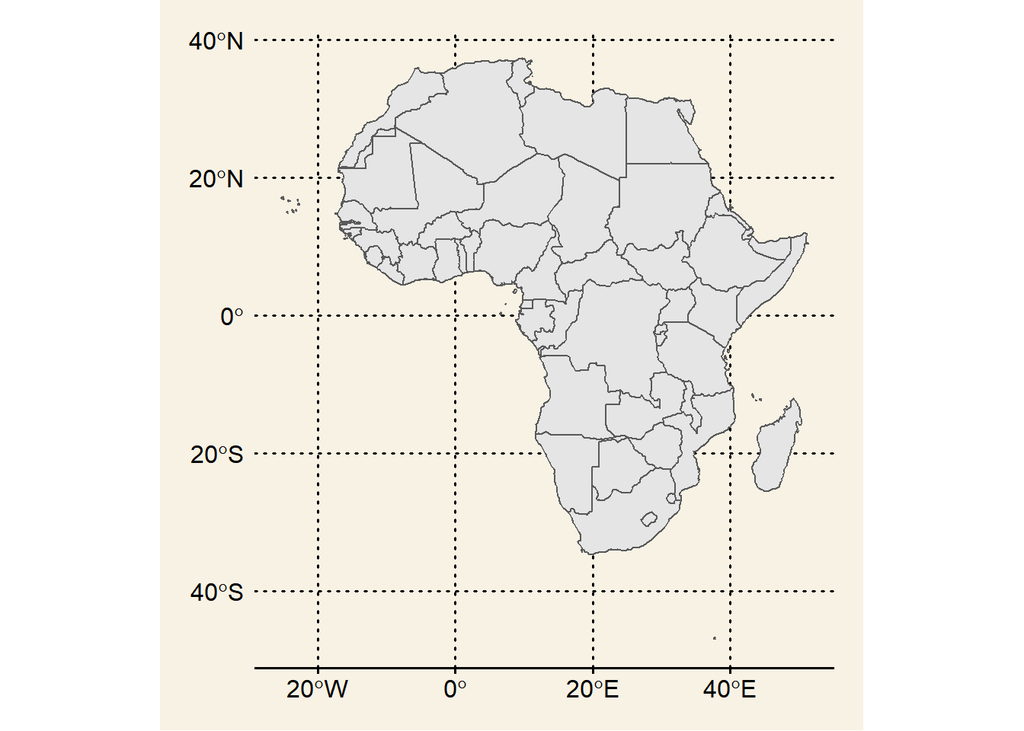

```r
#In case I want it later, creating world map first
world <- ne_countries(scale =50, returnclass ="sf")
# Create a variable for just African countries
map_africa <- world %>%
  filter(continent == "Africa")

#Plot it
af_map <- ggplot(map_africa) +
  geom_sf() +
  theme_wsj()
af_map
```

#### Setting Map Projections

```r
#Bonne (North Africa Bonne)
bonne_north_africa <- "+proj=bonne +lon_0=2.337208 +lat_1=35.1 +x_0=0 +y_0=0 +a=6378249.2 +b=6356514.999904194 +units=m +no_defs "
#Albers Equal Area - Africa
albers_africa <-"+proj=aea +lat_1=36.5 +lat_2=29.071428571429 +lat_0=32.7857142857145 +lon_0=-14.111111111111 +x_0=0 +y_0=0 +ellps=WGS84 +datum=WGS84 +units=m +no_defs"
#Africa Equidistant Conic
equi_conic <- "+proj=eqdc +lat_0=0 +lon_0=0 +lat_1=20 +lat_2=-23 +x_0=0 +y_0=0 +ellps=WGS84 +datum=WGS84 +units=m +no_defs "
```

#### North Africa Bonne

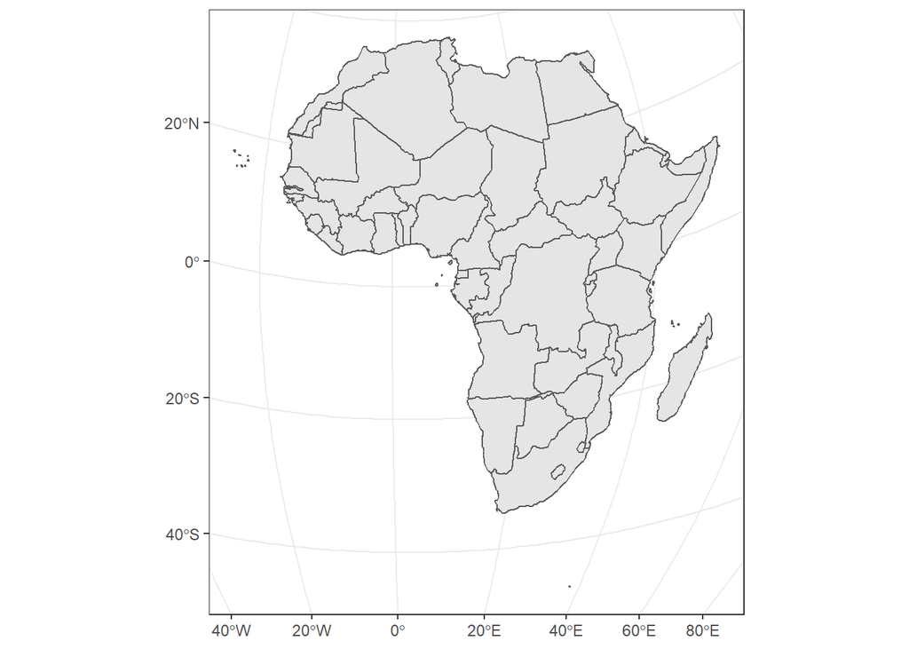

```r
ggplot(map_africa) +
  geom_sf() +
  coord_sf(crs= bonne_north_africa) +
  theme_bw()
```

#### ALbers Equal Area

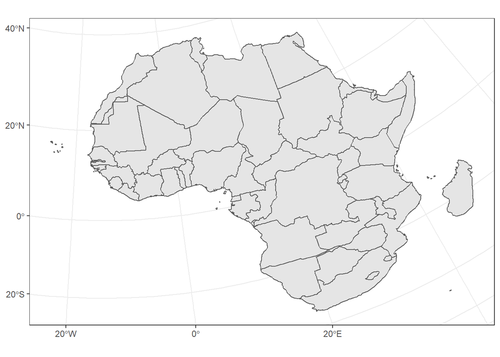

```r
ggplot(map_africa) +
  geom_sf() +
  coord_sf(crs= albers_africa) +
  theme_bw()
```

#### Africa Equidistant Conic

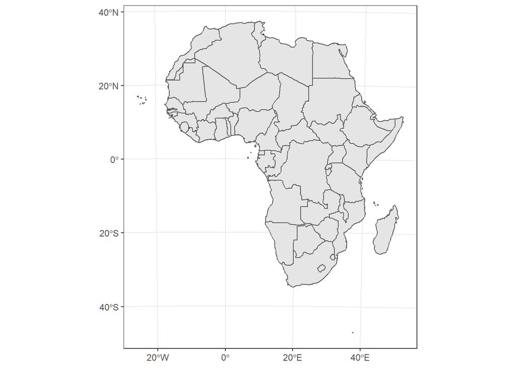

```r
ggplot(map_africa) +
  geom_sf() +
  coord_sf(crs= equi_conic) +
  theme_bw()
```

#### Loading Covid Data

```r
covid_data <-read_csv("owid-covid-data.csv")
```

## **Mapping Covid Data**

### Chloropleth Map

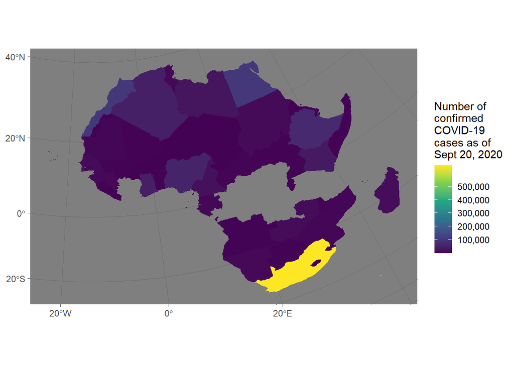

```r
covid_countries <- map_africa %>%
  left_join(covid_data, map_africa, by =c("sovereignt"="location"))%>%
  select(sovereignt, total_cases, geometry, income_grp, pop_est, new_cases)


  ggplot(covid_countries, aes(fill=total_cases)) +
    geom_sf(color=NA)+
    coord_sf(crs= albers_africa) +
    scale_fill_viridis_c(
    name = "Number of\nconfirmed\nCOVID-19\ncases as of\nSept 20, 2020",
    breaks = seq(100000, 500000, by = 100000),
    labels = formatC(seq(100000, 500000, by = 100000),
                     big.mark = ",", format = "f", digits = 0)) +
    theme_dark()
```

```r
 # covid_states <-states_transformed %>%
  #left_join(covid_us, by = c("name" = "Province_State")) %>%
  #mutate(pop = 100000 * Confirmed / Incident_Rate) %>%
  #select(name, pop, Confirmed, Deaths, Recovered, Active)
```

[output not shown]

### How to Pull up States

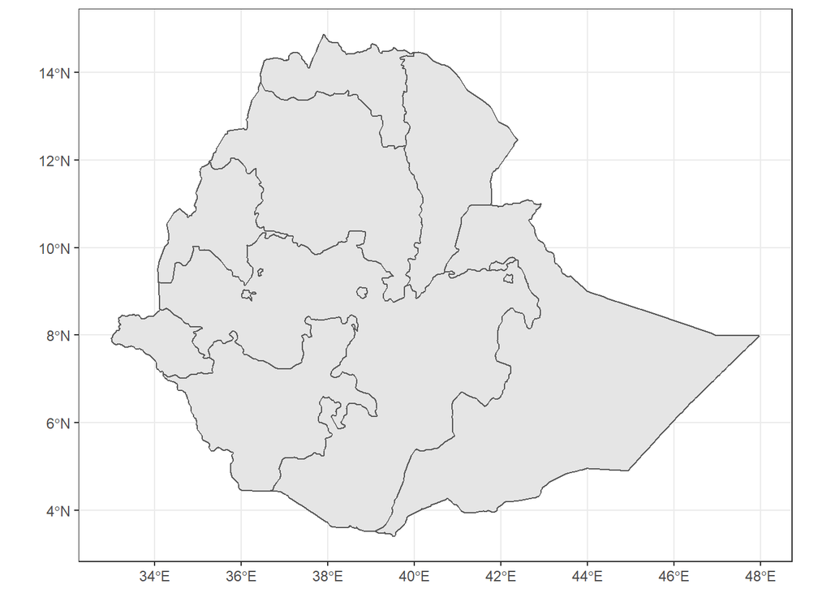

```r
ethiopia_states <-ne_states(country = "Ethiopia", returnclass="sf")

ethiopia_map <- ggplot(ethiopia_states) +
  geom_sf() +
  theme_bw()

ethiopia_map
```

## **R Cheat Sheet, References & Troubleshooting**

Hello! I see this area of my assignment as predominantly a resource for myself as I learn R and as a resource to R if I ever need to return after a hiatus (and have forgotten everything I know).

Feel free to look through, but there is no need to grade anything in this section.

** Sage’s Troubleshooting Checklist**  
0. Breathe.  
1. Is everything spelled/cApiTAlized correctly?  
2. Count your parentheses(), commas, and “quotes”  
2.1 Check poles %>%, |  
3. Have you run the R chunks that are before the chunk with your error.  
5. What is the last thing you changed? Did you make sure you changed it in ALL the places it needs to be changed?  
6. Breathe. Maybe get a glass of water.  
7. Type in the ?function() into the Console  
8. Do a Google search for “R Markdown” + Your Problem  
9. Try retyping the function from scratch. 10. Try copying and pasting sections in another R Chunk –> Isolate the Problem  
11. Phone a friend.

**Common Errors:**  
-If you are having a function not found error, check whether or not you have run your libraries.  
-YAML error, check the very beginning of your code -

**If you want to see the values of a variable as they appear in your dataset** #Race  
#unique(household_data$RAC1P_label) <br/> #Hispanic <br/> #unique(household_data$HISP_label)

### References

**For General R** R is for Data Science https://r4ds.had.co.nz/index.html

Data Wrangling Cheat Sheet https://rstudio.com/wp-content/uploads/2015/02/data-wrangling-cheatsheet.pdf

*formatting* https://rstudio.com/wp-content/uploads/2015/02/rmarkdown-cheatsheet.pdf

*For GGPLOT** Top 50 Graph Types http://r-statistics.co/Top50-Ggplot2-Visualizations-MasterList-R-Code.html#Violin%20Plot

GGplot Cheat Sheet https://rstudio.com/wp-content/uploads/2015/03/ggplot2-cheatsheet.pdf

Color Pallets https://www.datanovia.com/en/blog/ggplot-colors-best-tricks-you-will-love/#predefined-ggplot-color-palettes

Look into Wes Anderson Themes, WSJ, Economist

**Number Crunching**

Another Way of Pulling Summary  
#mean(household_data$HINCP) <br/> #quantile(household_data$HINCP)  
#sd(household_data$HINCP)

Simple Explanation of Dsitributions: https://nezumisa.wordpress.com/2013/06/03/different-types-of-distributions/